# Aula 2: Smart City ou Smart Citzen, onde mora a inteligência na cidade?

> Relembrando a aula anterior: "A cidade é .... da invenções humanas ..", portanto inventamos a cidade, logo, se ela é inteligente ........ , ou para ela se tornar inteligente ..........
- e continuamos inventando a cidade
- a cidade do futuro já existe, ninguém vai contruir uma nova

## Quem mora na cidade é **___**!

## Cidadania

https://www.miltonsantos.com.br/site/wp-content/uploads/2011/12/As-cidadanias-mutiladas_MiltonSantos1996-1997SITE.pdf

> "E afinal a cidadania, que é o exercicio de direitos e supõe a ciência dos direitos que temos e a capacidade de reivindicar seu exercício pleno e também de reivindicar mais. Como tudo isso está ligado ao grau de consciência, voltamos, por conseguinte, à questão da individualidade."

*Para quem quiser saber mais sobre Milton Santos https://www.brasildefato.com.br/2019/05/03/o-legado-de-milton-santos-um-novo-mundo-possivel-surgira-das-periferias*

## O espaço cidadão

> “Em lugar do cidadão formou-se um consumidor, que aceita ser chamado de usuário”

_https://edisciplinas.usp.br/pluginfile.php/4434323/mod_resource/content/1/Milton%20Santos%20-%20Espa%C3%A7o%20do%20Cidad%C3%A3o%20%28Cidadania%20Mutilada%29.pdf_

## Mas temos outros geógrafos, antropólogos, sociólogos ...

- David Harvey https://www.observatoriodasmetropoles.net.br/tag/david-harvey/
- Darcy Ribeiro https://monitormercantil.com.br/construcao-do-estado-nacional-cidadania-consciencia-ciep/
- Herbert de Souza (Betinho) https://cafecomsociologia.com/poder-do-cidadao-texto-de-herbet-de/
- Henri Lefebvre
- ....

## LAI (Lei de Acesso à Informação)

> A Lei nº 12.527, sancionada em 18 de novembro de 2011, regulamenta o direito constitucional de acesso dos cidadãos às informações públicas e é aplicável aos três poderes da União, dos estados, do Distrito Federal e dos municípios.

*https://www.gov.br/capes/pt-br/acesso-a-informacao/servico-de-informacao-ao-cidadao/sobre-a-lei-de-acesso-a-informacao*

## Dados Abertos

- Art 8. Par. 3, itens II e III da LAI - https://wiki.dados.gov.br/Legislacao.ashx
- Política de dados abertos - https://wiki.dados.gov.br/Legislacao.ashx
- Para saber mais:
  - https://ok.org.br/

## Cidadania e Dados Abertos - Casos práticos

- https://medidasp.com/genero-ruas.html
- https://ditamapa.desvirtual.com/pt/ - Prfa. Giselle Beiguelman (FAU/USP)
- https://urbit.com.br - Dá para ganhar dinheiro tb!
- https://piaui.folha.uol.com.br/tag/igualdades/
- https://github.com/okfn-brasil/serenata-de-amor - controle de contas da Adm. Publica

## Governo Aberto

- https://www.opengovpartnership.org
- Prefeitura de São Paulo https://www.prefeitura.sp.gov.br/cidade/secretarias/governo/governo_aberto_na_cidade_de_sao_paulo/index.php?p=252984
- Pierre Levy, filósofo - https://pt.wikipedia.org/wiki/Pierre_L%C3%A9vy
- Ciberdemocracia - http://copyfight.tk/Acervo/livros/LE%CC%81VY,%20Pierre.%20As%20Tecnologias%20da%20Intelige%CC%82ncia.pdf

## Empresas "abertas"

- https://labs.strava.com/
- https://developer.twitter.com/en
- https://movement.uber.com/cities?lang=en-US
- http://insideairbnb.com/get-the-data.html
- https://developers.facebook.com/docs/instagram

## Software livre

As quatro liberdades:

- Liberdade 0: A liberdade de execução do programa para qualquer finalidade;
- Liberdade 1: A liberdade de estudar e entender como o programa funciona, além de poder adaptá-lo de acordo com as suas necessidades. Para isso, o acesso ao código-fonte do software faz-se necessário;
- Liberdade 2: A liberdade de redistribuir cópias com o intuito de ajudar outras pessoas;
- Liberdade 3: A liberdade de distribuir cópias alteradas a outras pessoas. Isso permite que as demais pessoas tenham acesso ao software em sua versão melhorada, se beneficiando de suas mudanças.
- FreeWare != Software Livre
- FreeWare != Opensource
- Software Livre != Software Grátis

> Vamos olhar sem o viés da lógica capitalista?

## Pessoas por traz da comunidade de SL

- Richard Stallman - https://pt.wikipedia.org/wiki/Richard_Matthew_Stallman
- Linus Torvalds - https://pt.wikipedia.org/wiki/Linus_Torvalds

## Esse tal de GitHub

> Onde a comunidade de Software Livre Acontece, o Cyber Espaço
- https://github.com/

## Licenças criativas

- https://br.creativecommons.net/licencas/

## Licenças de software

- https://choosealicense.com/

> Vc já leu a licença do software ou da rede social que vc usa?

# Que tal praticar um pouco?

- http://dados.prefeitura.sp.gov.br/dataset/dados-do-sp156
- https://github.com/geoinfo-smdu/geo-sp156
- http://www.respeitoavida.sp.gov.br/relatorios/ (Enviado pela Denise)

```python
import pandas as pd
```

```python
df_acidentes = pd.read_csv("dados/acidentes_naofatais.csv", encoding='cp1252', sep=";")
```

```python
df_acidentes.columns
```

```
Index(['ID', 'Data do Acidente', 'Dia do Acidente', 'Mês do Acidente',
       'Ano do Acidente', 'Ano/Mês do Acidente', 'Dia da Semana',
       'Hora do Acidente', 'Turno', 'Município', 'Batalhão de Trânsito',
       'Companhia de Trânsito', 'Região Administrativa', 'Logradouro',
       'Numero/KM', 'Jurisdição', 'Administração', 'Conservação', 'LAT_(GEO)',
       'LONG_(GEO)', 'Condições Climáticas', 'Iluminação', 'Mão de direção',
       'Obras na pista', 'Relevo', 'Superfície da via', 'Tipo de pavimento',
       'Tipo de pista', 'Traçado', 'Veículos Envolvidos - Bicicleta',
       'Veículos Envolvidos - Caminhão', 'Veículos Envolvidos - Automóvel',
       'Veículos Envolvidos - Motocicleta', 'Veículos Envolvidos - Ônibus',
       'Veículos Envolvidos - Pedestre', 'Pessoas Envolvidas - Grave',
       'Pessoas Envolvidas - Ileso', 'Pessoas Envolvidas - Leve',
       'Serviço de Atendimento - Bombeiro', 'Serviço de Atendimento - PMRV',
       'Serviço de Atendimento - PRF',
       'Serviço de Atendimento - Radio Patrulha',
       'Servciço de Atendimento - CPTRAN', 'Tipo de Via',
       'Tipo de Acidente - Atropelamento', 'Tipo de Acidente - Choque',
       'Tipo de Acidente - Colisão',
       'Tipo de Acidente - Outros tipos de Acidente', 'Turno + Dia de Semana'],
      dtype='object')
```

```python
df_acidentes['Ano do Acidente'].value_counts()
```

```
2019    183863
2020    166615
2021    116618
Name: Ano do Acidente, dtype: int64
```

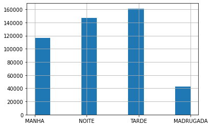

```python
df_acidentes['Turno'].astype(str).hist()
```

```python
df_acidentes['Município'].value_counts()
```

```
SAO PAULO                107108
GUARULHOS                 13257
CAMPINAS                  10521
RIBEIRAO PRETO            10155
SAO JOSE DO RIO PRETO      9833
                          ...
BORA                          5
BARAO DE ANTONINA             4
DIRCE REIS                    4
ARAPEI                        4
NOVA CASTILHO                 1
Name: Município, Length: 645, dtype: int64
```

```python
df_acidentes[df_acidentes['Município'] == "GUARULHOS"]
```

|  | ID | Data do Acidente | Dia do Acidente | Mês do Acidente | Ano do Acidente | Ano/Mês do Acidente | Dia da Semana | Hora do Acidente | Turno | Município | ... | Serviço de Atendimento - PMRV | Serviço de Atendimento - PRF | Serviço de Atendimento - Radio Patrulha | Servciço de Atendimento - CPTRAN | Tipo de Via | Tipo de Acidente - Atropelamento | Tipo de Acidente - Choque | Tipo de Acidente - Colisão | Tipo de Acidente - Outros tipos de Acidente | Turno + Dia de Semana |
| --- | --- | --- | --- | --- | --- | --- | --- | --- | --- | --- | --- | --- | --- | --- | --- | --- | --- | --- | --- | --- | --- |
| 1 | 1878460 | 2021-08-31 | 31 | AGOSTO | 2021 | 2021.08 | TERÇA | 07:01 | MANHA | GUARULHOS | ... | NÃO | NÃO | SIM | NÃO | Vias Municipais | 0 | 0 | 1 | 0 | MANHA DE TERÇA |
| 15 | 1877984 | 2021-08-31 | 31 | AGOSTO | 2021 | 2021.08 | TERÇA | 16:12 | TARDE | GUARULHOS | ... | NÃO | NÃO | NÃO | NÃO | Rodovias | 0 | 0 | 0 | 0 | TARDE DE TERÇA |
| 203 | 1897083 | 2021-08-31 | 31 | AGOSTO | 2021 | 2021.08 | TERÇA | 15:50 | TARDE | GUARULHOS | ... | NÃO | SIM | NÃO | NÃO | Rodovias | 0 | 0 | 1 | 1 | TARDE DE TERÇA |
| 206 | 1897092 | 2021-08-31 | 31 | AGOSTO | 2021 | 2021.08 | TERÇA | 22:53 | NOITE | GUARULHOS | ... | NÃO | SIM | NÃO | NÃO | Rodovias | 0 | 0 | 0 | 0 | NOITE DE TERÇA |
| 211 | 1903595 | 2021-08-31 | 31 | AGOSTO | 2021 | 2021.08 | TERÇA | 10:07 | MANHA | GUARULHOS | ... | NÃO | NÃO | NÃO | NÃO | Vias Municipais | 0 | 0 | 0 | 0 | MANHA DE TERÇA |
| ... | ... | ... | ... | ... | ... | ... | ... | ... | ... | ... | ... | ... | ... | ... | ... | ... | ... | ... | ... | ... | ... |
| 467015 | 906984 | 2019-01-01 | 1 | JANEIRO | 2019 | 2019.01 | TERÇA | 01:18 | MADRUGADA | GUARULHOS | ... | NÃO | NÃO | NÃO | NÃO | Rodovias | 0 | 0 | 0 | 0 | MADRUGADA DE TERÇA |
| 467060 | 906956 | 2019-01-01 | 1 | JANEIRO | 2019 | 2019.01 | TERÇA | 03:08 | MADRUGADA | GUARULHOS | ... | NÃO | NÃO | NÃO | NÃO | Vias Municipais | 0 | 0 | 0 | 0 | MADRUGADA DE TERÇA |
| 467064 | 907016 | 2019-01-01 | 1 | JANEIRO | 2019 | 2019.01 | TERÇA | 13:38 | TARDE | GUARULHOS | ... | NÃO | NÃO | NÃO | NÃO | Rodovias | 0 | 0 | 0 | 0 | TARDE DE TERÇA |
| 467071 | 907055 | 2019-01-01 | 1 | JANEIRO | 2019 | 2019.01 | TERÇA | 21:39 | NOITE | GUARULHOS | ... | NÃO | NÃO | NÃO | NÃO | Vias Municipais | 0 | 0 | 0 | 0 | NOITE DE TERÇA |
| 467081 | 907092 | 2019-01-01 | 1 | JANEIRO | 2019 | 2019.01 | TERÇA | 18:57 | NOITE | GUARULHOS | ... | NÃO | NÃO | NÃO | NÃO | Vias Municipais | 0 | 0 | 0 | 0 | NOITE DE TERÇA |

13257 rows × 49 columns

```python
df_acidentes.loc[:, ['LAT_(GEO)', 'LONG_(GEO)']]
```

|  | LAT_(GEO) | LONG_(GEO) |
| --- | --- | --- |
| 0 | -20,512088827 | -47,385248546 |
| 1 | -23,452269736 | -46,474724234 |
| 2 | NaN | NaN |
| 3 | -20,5165800229714 | -47,4133219208857 |
| 4 | -21,0435119724842 | -49,6818260096159 |
| ... | ... | ... |
| 467091 | -23,75 | -46,6976 |
| 467092 | -23,6449 | -46,6719 |
| 467093 | -23,4553 | -46,5776 |
| 467094 | -23,4503345968 | -46,6521888768 |
| 467095 | -23,4366 | -46,7372 |

467096 rows × 2 columns

## Como mentir com mapas?

- https://openlibrary.org/books/OL1880196M/How_to_Lie_with_Maps
- http://www.dpi.inpe.br/gilberto/infogeo/infogeo15.pdf
- https://open.lib.umn.edu/mapping/chapter/7-lying-with-maps/